# LSE ST510: Foundations of Machine Learning

## Week 8: Unsupervised Learning - Clustering

### Author: Jin Zhu

- 8.1 K-Means Clustering
- 8.2 Hierarchical Clustering
- 8.3 Spectral Clustering

```python
import pandas as pd
import numpy as np
import matplotlib as mpl
import matplotlib.pyplot as plt
import seaborn as sns

from sklearn.metrics import pairwise_distances
from sklearn.preprocessing import scale
from sklearn.datasets import make_circles
from sklearn.cluster import KMeans, AgglomerativeClustering, SpectralClustering

from scipy.cluster import hierarchy
from scipy.cluster.hierarchy import cut_tree

import warnings
warnings.simplefilter('ignore')

from IPython.display import display

%matplotlib inline
plt.style.use('seaborn-white')
```

Generate data with 2 clusters.

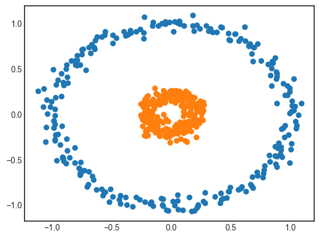

```python
# Synthetic classification dataset
X, y = make_circles(n_samples = 500, noise = .05, factor = .2, random_state = 0)
# scatter plot
for i in range(2):
    X_row = np.where(y == i)
    mpl.pyplot.scatter(X[X_row, 0], X[X_row, 1])
mpl.pyplot.show()
```

```python
pd.Series(y).value_counts()
```

```
0    250
1    250
dtype: int64
```

## 8.1 K-Means Clustering

`n_clusters` is the number of clusters to form as well as the number of centroids to generate.

`n_init` is the number of time the k-means algorithm will be run with different centroid seeds. The final results will be the best output of `n_init` consecutive runs in terms of inertia. Inertia is the sum of squared distances of samples to their closest cluster center.

Here we compare using `n_init=1` to `n_init=50`. We attempt to minimize the inertia/total within-cluster sum of squares.

```python
# K = 2
km1 = KMeans(n_clusters = 2, n_init = 1, random_state = 1)
km1.fit(X)

# Inertia
km1.inertia_
```

```
191.21018307993666
```

```python
# K = 2
km1 = KMeans(n_clusters = 2, n_init = 50, random_state = 1)
km1.fit(X)

km1.inertia_
```

```
187.9631538329325
```

We strongly recommend running K-means clustering with a large value of `n_init`, such as 20 or 50. Otherwise, an undesirable local optimum may be obtained.

```python
# Labels of the first 10 points
display(km1.labels_[:10])

display(pd.Series(km1.labels_).value_counts())
```

```
array([1, 1, 1, 0, 0, 1, 1, 0, 0, 0], dtype=int32)
```

```
1    255
0    245
dtype: int64
```

```python
# Coordinates of cluster centers
km1.cluster_centers_
```

```
array([[-0.01373135, -0.39943215],
       [ 0.01290789,  0.3778884 ]])
```

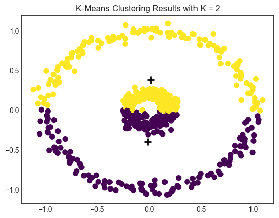

```python
plt.scatter(X[:,0], X[:,1], s = 50, c = km1.labels_, cmap = 'viridis')
plt.title('K-Means Clustering Results with K = 2')
plt.scatter(km1.cluster_centers_[:,0], km1.cluster_centers_[:,1], marker = '+', s = 100, c = 'k', linewidth = 2)
```

Use "Overfit then Merge" method: Choose large $K$, then merge close clusters.

```python
# K = 4
km2 = KMeans(n_clusters = 4, n_init = 50, random_state = 1)
km2.fit(X)
pd.Series(km2.labels_).value_counts()
```

```
0    250
2     85
3     84
1     81
dtype: int64
```

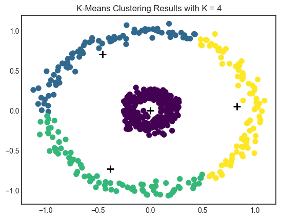

```python
plt.scatter(X[:,0], X[:,1], s = 50, c = km2.labels_, cmap = 'viridis')
plt.title('K-Means Clustering Results with K = 4')
plt.scatter(km2.cluster_centers_[:,0], km2.cluster_centers_[:,1], marker = '+', s = 100, c = 'k', linewidth = 2)
```

## 8.2 Hierarchical Clustering

Use **Euclidean distance** as the dissimilarity measure.

```python
clustering_complete = AgglomerativeClustering(linkage='complete').fit(X)
clustering_average = AgglomerativeClustering(linkage='average').fit(X)
clustering_single = AgglomerativeClustering(linkage='single').fit(X)
```

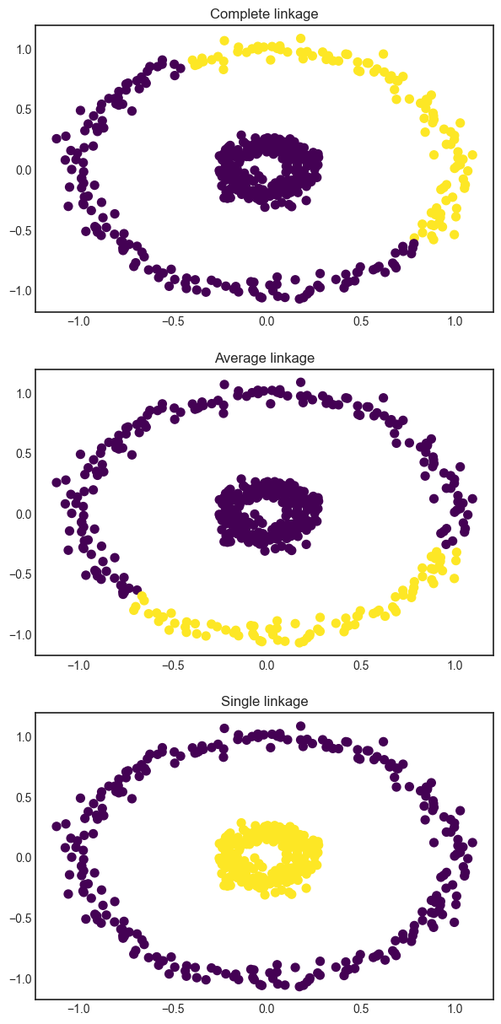

```python
fig, (ax1, ax2, ax3) = plt.subplots(3, 1, figsize = (7,15))

ax1.scatter(X[:,0], X[:,1], s = 50, c = clustering_complete.labels_, cmap = 'viridis')
ax1.set_title('Complete linkage')

ax2.scatter(X[:,0], X[:,1], s = 50, c = clustering_average.labels_, cmap = 'viridis')
ax2.set_title('Average linkage')

ax3.scatter(X[:,0], X[:,1], s = 50, c = clustering_single.labels_, cmap = 'viridis')
ax3.set_title('Single linkage')
```

Single linkage separates the observations into their correct groups.

Now we can plot the hierarchical clustering as a dendrogram. To scale the variables before performing hierarchical clustering of the observations, we use `scale()` function from `sklearn.preprocessing`.

```python
clustering_complete = hierarchy.complete(scale(X))
clustering_average = hierarchy.average(scale(X))
clustering_single = hierarchy.single(scale(X))
```

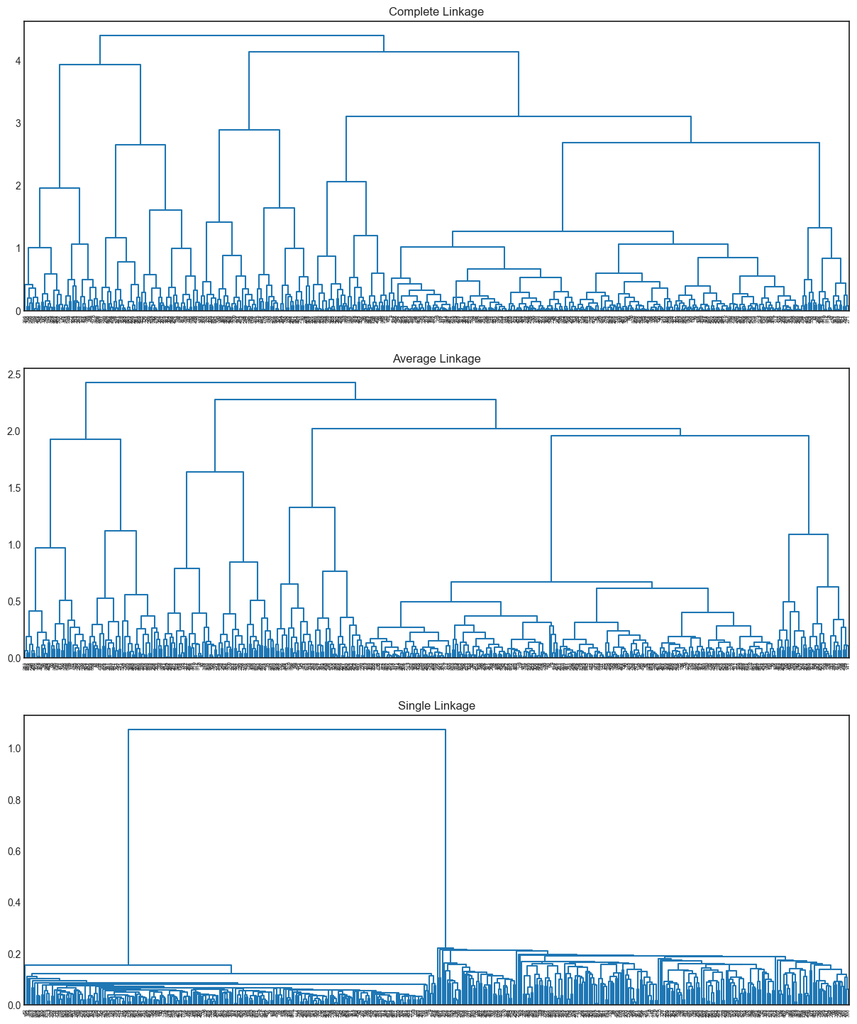

```python
fig, (ax1, ax2, ax3) = plt.subplots(3, 1, figsize = (15,18))
for linkage, ax in zip([clustering_complete, clustering_average, clustering_single], [ax1, ax2, ax3]):
    cluster = hierarchy.dendrogram(linkage, ax = ax, color_threshold = 0)

ax1.set_title('Complete Linkage')
ax2.set_title('Average Linkage')
ax3.set_title('Single Linkage');
```

Determine the cluster labels for each observation associated with a given cut of the dendrogram.

```python
print(cut_tree(clustering_single, n_clusters = 2).T)
```

```
[[0 1 1 1 1 0 1 1 0 0 0 1 1 1 0 1 1 1 0 0 0 1 0 0 0 1 0 1 0 0 1 0 0 0 1 1
  1 1 1 0 1 0 1 0 0 0 0 1 1 0 1 0 1 0 0 0 1 0 0 1 0 1 1 1 1 0 0 1 1 0 0 0
  1 1 0 1 1 0 1 1 1 0 1 0 1 1 1 0 1 0 0 1 1 0 0 1 0 1 0 0 0 1 0 1 0 1 0 0
  1 0 1 0 0 0 1 1 1 1 0 0 1 0 0 1 1 0 0 1 1 1 1 0 1 0 1 1 1 1 1 0 0 0 0 0
  1 0 1 1 0 0 0 1 0 1 0 0 0 0 1 0 1 0 0 1 0 0 1 1 1 1 1 0 1 1 1 0 1 0 1 1
  1 0 0 1 0 1 1 1 1 0 1 1 0 1 1 1 1 0 0 0 0 0 0 1 0 1 0 1 0 1 1 0 0 1 0 1
  0 0 0 1 0 0 0 0 1 1 0 0 0 0 1 0 1 0 1 1 1 0 0 1 0 0 1 1 1 1 1 0 0 0 1 0
  0 0 0 0 0 0 1 0 0 0 1 0 1 1 1 0 0 1 1 0 1 1 0 0 0 1 1 1 0 1 0 0 0 0 1 0
  0 0 0 0 0 0 1 1 0 1 1 0 1 1 0 1 1 1 0 0 0 1 1 0 0 0 0 1 0 1 0 0 1 1 1 1
  1 0 1 0 1 1 1 0 1 0 1 0 1 1 0 0 1 1 1 1 1 0 1 0 1 1 0 1 0 1 0 1 0 0 1 0
  0 1 1 1 0 0 0 1 0 0 0 0 1 0 0 1 1 0 1 1 1 0 1 1 0 1 0 1 0 0 1 0 1 1 0 1
  0 0 0 1 0 1 0 1 1 1 1 0 0 0 1 1 1 1 1 0 0 1 0 1 1 0 1 1 1 1 0 0 1 1 1 1
  0 1 0 1 1 0 1 0 0 1 0 0 0 0 0 0 0 0 1 1 1 1 1 1 0 1 1 0 0 1 1 1 1 0 0 1
  0 1 1 0 1 0 0 1 1 0 1 0 0 1 1 0 1 0 0 1 0 1 0 0 1 0 1 1 0 0 0 0]]
```

Use the **correlation-based distance** as the dissimilarity measure.

First, we need to calculate the correlation-based distance. This only makes sense for data with at least three features since the absolute correlation between any two observations with measurements on two features is always 1. Hence we will generate a three-dimensional dataset.

Similar shape corresponds to the correlation closer to $1$, hence we consider $1 -$ correlation as the dissimilarity measure. The closer to $0$ this value is, the more similarity we have.

```python
np.random.seed(1)
x = np.random.standard_normal((30,3))
df = pd.DataFrame(x)
corr = pairwise_distances(df, metric = "correlation")
```

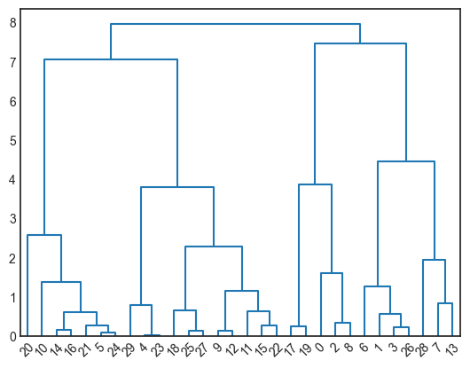

```python
clustering_complete = hierarchy.complete(corr)
hierarchy.dendrogram(clustering_complete, color_threshold = 0)
plt.show()
```

## 8.3 Spectral Clustering

Implement spectral clustering using a radial basis function (RBF) kernel. Please play with `SpectralClustering` with different input parameters. You will be required to implement different spectral clustering methods via simulations in this week's assessment.

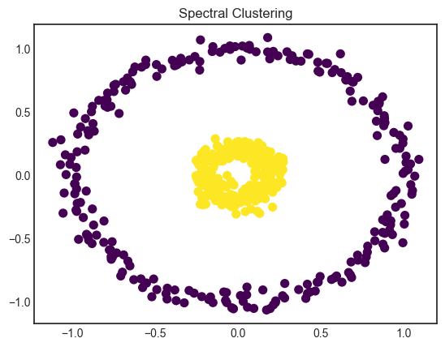

```python
spectral1 = SpectralClustering(n_clusters = 2, n_init=50, affinity='rbf', gamma=4.5, random_state=1).fit(X)
plt.scatter(X[:,0], X[:,1], s = 50, c=spectral1.labels_, cmap='viridis')
plt.title('Spectral Clustering')
```